# Texto 4 - Educação básica da população negra

Pablo Castro

19/06/2026

# 1 Introdução

A educação básica constitui o alicerce do desenvolvimento humano e social, sendo componente essencial da agenda de promoção da igualdade racial no Brasil. Este texto, quarto do conjunto de nove análises temáticas previstas no Contrato IC nº 000199/2025-0, integra o Produto 3 e foca especificamente na educação básica da população negra (pretos e pardos), com desagregação por sexo e recortes territoriais.

Em conformidade com o Plano de Trabalho Geral, a análise utiliza microdados do Censo Demográfico 2022 e do Sistema de Avaliação da Educação Básica (SAEB/INEP) para construir indicadores sobre taxa de frequência escolar, adequação idade-série e proficiência nos ensinos fundamental e médio, com recortes por raça/cor, sexo, região e, sempre que os dados permitem, município. Os resultados são organizados em visualizações sintéticas que evidenciam desigualdades estruturais, comparações regionais e municipais, e implicações para políticas públicas, incluindo o Sistema Nacional de Promoção da Igualdade Racial (SINAPIR) e programas federais de educação básica.

# 2 Acesso e Frequência Escolar da População Negra no Brasil

Esta seção apresenta uma análise detalhada dos indicadores de acesso e frequência à escola por idade, série e etapa de ensino (educação infantil, ensino fundamental e ensino médio), com recortes por raça/cor, sexo e território. Os dados permitem identificar padrões de desigualdade racial na trajetória escolar da população brasileira e avaliar o acesso diferenciado às diferentes etapas da educação básica.

## 2.1 Composição Racial por Etapa de Ensino

A Figura 2.1 apresenta a composição racial dos estudantes brasileiros segundo a etapa de ensino frequentada. Os resultados evidenciam que a população negra é majoritária em todas as etapas da educação básica, refletindo a composição demográfica do país, onde negros (pretos e pardos) representam mais de 55% da população total.

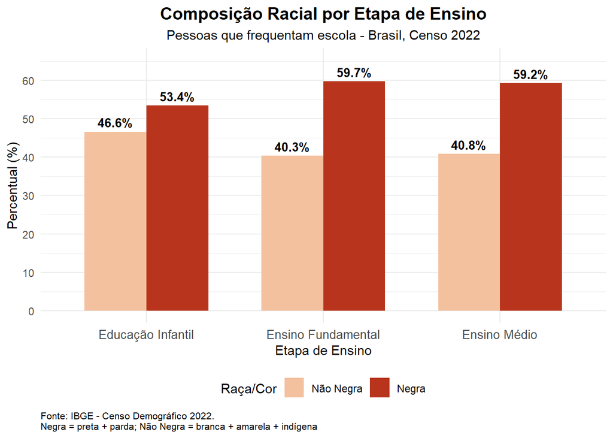

Figure 2.1: Composição Racial por Etapa de Ensino

Na Educação Infantil, a população negra representa 53,4% dos estudantes, contra 46,6% de não negros. Essa proporção aumenta no Ensino Fundamental, onde estudantes negros correspondem a 59,7% do total, e se mantém praticamente estável no Ensino Médio (59,2%). O crescimento da participação negra entre a Educação Infantil e o Ensino Fundamental (aumento de 6,3 pontos percentuais) sugere uma progressiva universalização do acesso à escola entre crianças negras, mas também pode refletir diferenças na cobertura da educação infantil, historicamente mais restrita e seletiva.

Esse padrão indica que, embora a população negra seja maioria absoluta dos estudantes brasileiros, sua proporção varia entre as etapas de ensino, o que pode estar associado tanto a fatores demográficos quanto a desigualdades no acesso e na progressão escolar ao longo da trajetória educacional.

## 2.2 Frequência Escolar por Grupo de Idade e Raça/Cor

A Figura 2.2 detalha a frequência escolar segundo grupos de idade e raça/cor, permitindo observar a distribuição etária dos estudantes. Os dados mostram que, em todas as faixas etárias obrigatórias (6 a 17 anos), a população negra representa a maioria dos estudantes matriculados.

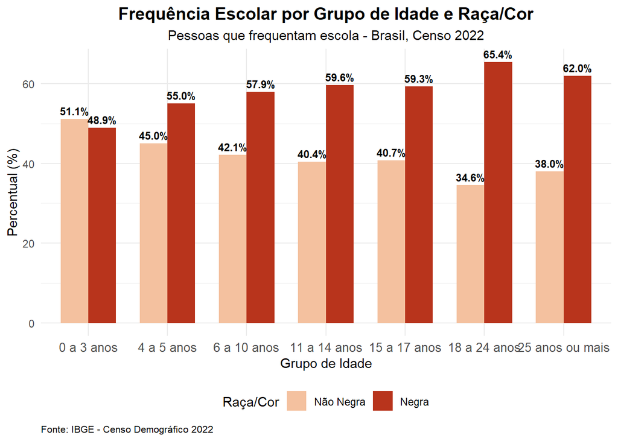

Figure 2.2: Frequência Escolar por Grupo de Idade e Raça/Cor

Esses dados evidenciam não apenas a maior presença proporcional de estudantes negros no sistema educacional brasileiro, mas também a importância de políticas públicas que considerem as especificidades e vulnerabilidades desse grupo ao longo de toda a trajetória escolar.

## 2.3 Frequência Escolar por Idade, Raça/Cor e Sexo

A Figura 2.3 incorpora o recorte de gênero à análise, revelando padrões importantes de desigualdade interseccional. A distribuição de estudantes entre homens e mulheres é relativamente equilibrada em todas as faixas etárias, mas a composição racial permanece consistente, com maioria negra em ambos os sexos.

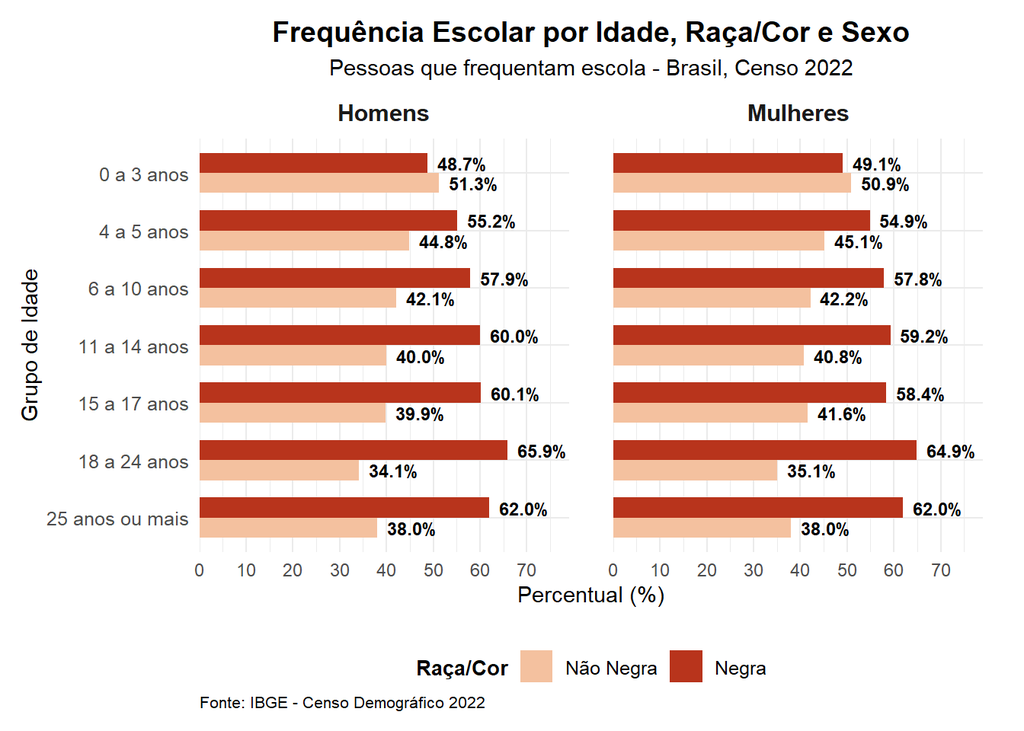

Figure 2.3: Frequência Escolar por Idade, Raça/Cor e Sexo

Entre homens, a população negra representa proporções variáveis ao longo das faixas etárias: aproximadamente 49% na primeira infância (0 a 3 anos), aumentando para 58% a 60% nas idades escolares (6 a 17 anos), e alcançando 62% a 66% nas faixas adultas (18 anos ou mais). Entre mulheres, o padrão é semelhante, com participação negra variando de 49% na primeira infância, 58% a 59% no período escolar básico, e chegando a 62% a 65% nas faixas adultas. Não se observam diferenças expressivas entre homens e mulheres quanto à composição racial dentro de cada faixa etária, indicando que as desigualdades raciais no acesso à educação afetam de forma similar ambos os sexos.

Esse resultado sugere que, embora existam desigualdades de gênero na educação brasileira — especialmente em indicadores de desempenho e progressão escolar —, a composição racial da frequência escolar é consistente entre meninos e meninas dentro de cada grupo etário.

## 2.4 Composição Racial por Nível de Ensino Detalhado

A Figura 2.4 apresenta a composição racial segundo o nível de ensino frequentado de forma mais desagregada, incluindo creche, pré-escola, ensino fundamental regular, ensino médio regular e modalidades de educação de jovens e adultos (EJA).

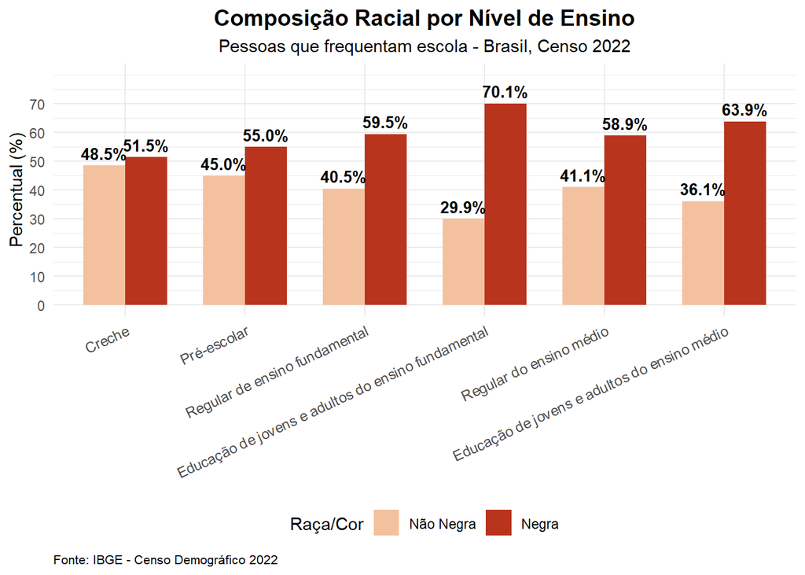

Figure 2.4: Composição Racial por Nível de Ensino Detalhado

Essa concentração de estudantes negros nas modalidades de EJA é um indicador importante de desigualdade racial acumulada. A EJA é frequentada predominantemente por pessoas que não completaram a educação básica na idade adequada, seja por evasão, interrupção ou ingresso tardio na escola. A sobrerrepresentação de negros nessas modalidades evidencia que a população negra enfrenta maiores dificuldades para seguir a trajetória escolar regular, refletindo barreiras estruturais ao acesso e à permanência na escola ao longo das gerações.

## 2.5 Composição Racial dos Estudantes por Região

A Figura 2.5 apresenta a composição racial dos estudantes segundo as cinco grandes regiões brasileiras, revelando marcantes diferenças territoriais na distribuição da população escolar.

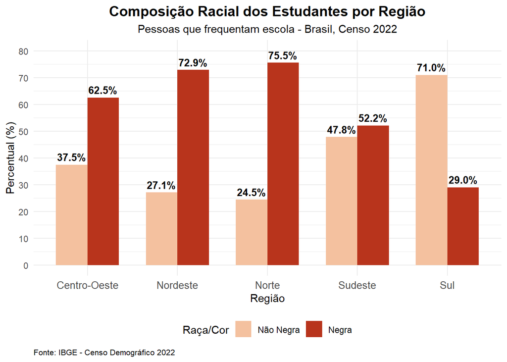

Figure 2.5: Composição Racial dos Estudantes por Região

As regiões Norte e Nordeste apresentam as maiores proporções de estudantes negros, com 75,5% e 72,9%, respectivamente. Essas são também as regiões com maior proporção de população negra no país, historicamente marcadas por processos de ocupação territorial, migração interna e persistência de desigualdades socioeconômicas que afetam de forma desproporcional a população afrodescendente (Telles, 2004).

A região Centro-Oeste apresenta 62,5% de estudantes negros, proporção próxima à média nacional. Já o Sudeste registra equilíbrio relativo entre os grupos raciais, com 52,2% de estudantes negros e 47,8% de não negros. A região Sul destaca-se com a composição inversa às demais: estudantes não negros são maioria (71,0%), enquanto negros representam apenas 29,0%, refletindo a formação histórica dessa região, marcada pela imigração europeia e menor presença da população afrodescendente.

Essas diferenças regionais reforçam a importância de políticas educacionais territorialmente sensíveis, que considerem as especificidades demográficas e socioeconômicas de cada região do país.

## 2.6 Distribuição Territorial de Estudantes Negros por Unidade Federativa

A Figura 2.6 apresenta o percentual de estudantes negros por Unidade Federativa, permitindo visualizar com maior precisão a heterogeneidade espacial da composição racial nas escolas brasileiras.

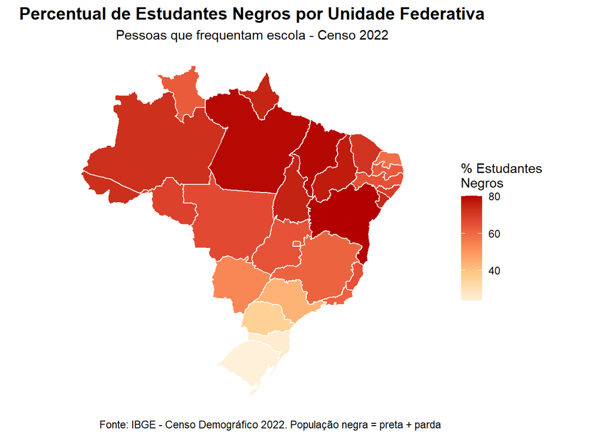

Figure 2.6: Distribuição Territorial de Estudantes Negros por Unidade Federativa

Os estados do Norte e Nordeste apresentam os maiores percentuais de estudantes negros, com destaque para Maranhão, Piauí, Bahia, Amapá e Pará, onde a proporção ultrapassa 75%. No Nordeste, todos os estados apresentam maioria negra nas escolas, com percentuais que variam entre 65% e 80%.

A região Sul se diferencia com as menores proporções de estudantes negros do país. Santa Catarina e Rio Grande do Sul registram percentuais entre 15% e 30%, refletindo a composição demográfica regional. Paraná apresenta proporção intermediária (cerca de 35%), situando-se entre o padrão do Sul e das demais regiões.

Essa distribuição espacial evidencia que as desigualdades raciais na educação brasileira possuem forte componente territorial, associado aos processos históricos de ocupação, migração e formação da população em cada região (Telles, 2004).

## 2.7 Frequência Escolar da População Negra por Município

A Figura 2.6 acima é construído a partir de dados do Censo 2022, disponíveis apenas ao nível de Unidade Federativa nas tabelas de frequência escolar utilizadas neste texto. Para complementar essa visão com maior granularidade territorial, o Figura 2.7 apresenta a taxa de frequência escolar da população negra de 6 a 14 anos por município, a partir da Tabela 10056 do Censo 2022 (mesma base utilizada na Seção 2 para o hiato municipal).[^1]

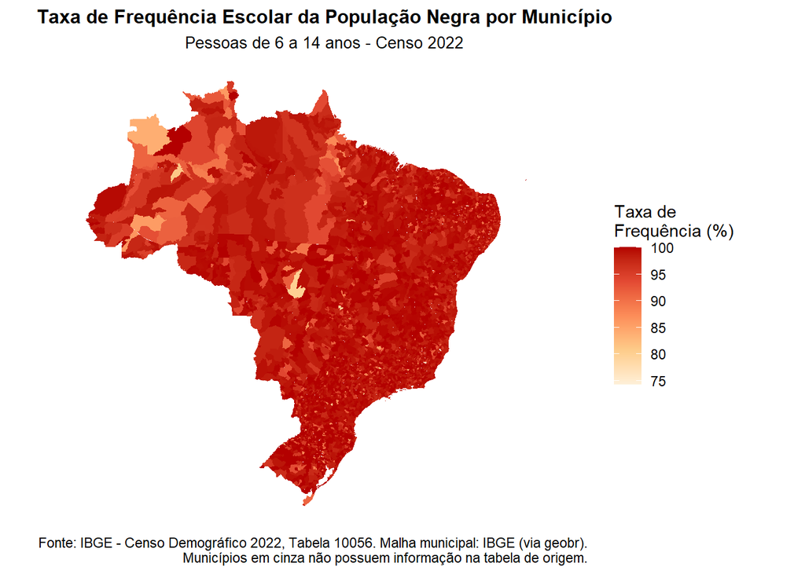

Figure 2.7: Taxa de Frequência Escolar da População Negra por Município (6 a 14 anos)

O mapa municipal revela uma heterogeneidade substancialmente maior do que a observada ao nível de UF: dentro de um mesmo estado, é possível identificar municípios com taxas de frequência da população negra bastante distintas, refletindo padrões locais de oferta escolar, infraestrutura e vulnerabilidade socioeconômica que o recorte estadual tende a homogeneizar. Essa granularidade municipal é especialmente relevante para o direcionamento de políticas educacionais antirracistas a territórios específicos, complementando o diagnóstico nacional e regional apresentado nas demais seções e o hiato municipal detalhado na próxima subseção.

## 2.8 Recorte Municipal: Hiato de Frequência Escolar entre Negros e Não Negros

As análises por Unidade Federativa ocultam uma heterogeneidade importante: dentro de um mesmo estado, municípios podem apresentar realidades muito distintas quanto ao acesso escolar da população negra. Para captar essa variação, o Figura 2.8 apresenta a distribuição do hiato municipal de frequência escolar entre não negros e negros, na faixa de 6 a 14 anos (idade de escolarização obrigatória no Ensino Fundamental), calculado a partir da Tabela 10056 do Censo 2022 ao nível de município.[^2]

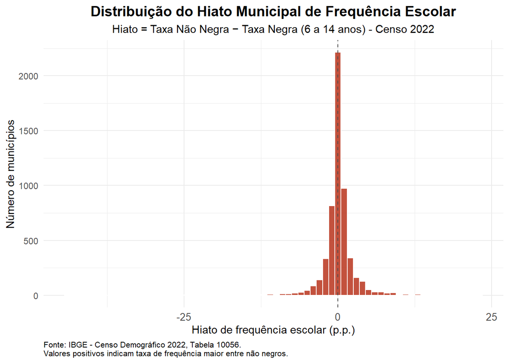

Figure 2.8: Distribuição do Hiato Municipal de Frequência Escolar (6 a 14 anos)

A maior parte dos municípios brasileiros concentra-se em torno de um hiato próximo de zero, refletindo a quase universalização do acesso à escola nessa faixa etária obrigatória. Ainda assim, observa-se uma cauda relevante de municípios em que a taxa de frequência de crianças e adolescentes não negros supera a de negros em vários pontos percentuais, e também municípios no sentido inverso.

A Tabela 2.1 lista os dez municípios com maior hiato em desfavor da população negra, evidenciando que a desigualdade racial no acesso à escola, embora pequena em termos nacionais, permanece concentrada em territórios específicos.

Table 2.1: Municípios com maior hiato racial de frequência escolar (6 a 14 anos)

| Município | UF | Região | Taxa Negra (%) | Taxa Não Negra (%) | Hiato (p.p.) |
| --- | --- | --- | --- | --- | --- |
| Lajes Pintadas | RN | Nordeste | 76.9 | 100.0 | 23.1 |
| Antônio Martins | RN | Nordeste | 75.3 | 96.5 | 21.1 |
| Santa Bárbara do Tugúrio | MG | Sudeste | 82.3 | 100.0 | 17.7 |
| Conceição da Aparecida | MG | Sudeste | 81.9 | 99.5 | 17.6 |
| Goianápolis | GO | Centro-Oeste | 81.1 | 98.4 | 17.3 |
| Itapuranga | GO | Centro-Oeste | 79.8 | 95.2 | 15.3 |
| Uarini | AM | Norte | 81.1 | 96.3 | 15.1 |
| Rancho Queimado | SC | Sul | 84.3 | 99.3 | 15.0 |
| Pirapó | RS | Sul | 82.4 | 97.2 | 14.8 |
| Espera Feliz | MG | Sudeste | 75.0 | 89.8 | 14.8 |

Esse recorte municipal reforça a necessidade de políticas educacionais territorialmente direcionadas: a focalização exclusivamente regional ou estadual pode mascarar municípios críticos onde o hiato racial é substancialmente mais agudo do que sugerem as médias agregadas.

## 2.9 Frequência Escolar por Etapa de Ensino e Região

A Figura 2.9 apresenta a composição racial dos estudantes por etapa de ensino em cada região, permitindo identificar como as desigualdades raciais variam territorialmente ao longo da trajetória escolar.

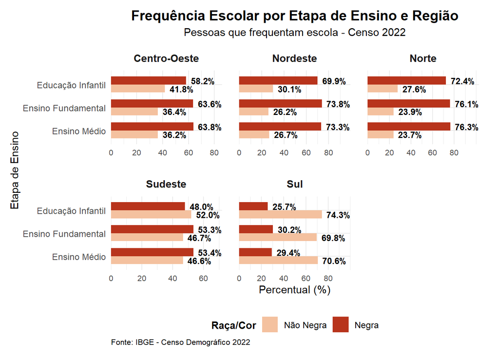

Figure 2.9: Frequência Escolar por Etapa de Ensino e Região

No **Norte**, a população negra é amplamente majoritária em todas as etapas: 72,4% na Educação Infantil, 76,1% no Ensino Fundamental e 76,3% no Ensino Médio. O ligeiro aumento da participação negra entre a Educação Infantil e o Ensino Médio sugere que, nessa região, estudantes negros têm conseguido progredir na trajetória escolar de forma consistente.

No **Nordeste**, o padrão é similar, com participação negra de 69,9% na Educação Infantil, 73,8% no Ensino Fundamental e 73,3% no Ensino Médio. A estabilidade desses percentuais indica universalização relativamente equitativa do acesso entre os grupos raciais ao longo da educação básica.

O **Centro-Oeste** apresenta proporções elevadas e estáveis: 58,2% na Educação Infantil, 63,6% no Ensino Fundamental e 63,8% no Ensino Médio. O aumento entre a Educação Infantil e o Ensino Fundamental pode refletir menor cobertura da educação infantil entre a população branca, historicamente mais presente em redes privadas.

## 2.10 Adequação Idade-Série por Raça/Cor

A Figura 2.10 analisa a adequação idade-série segundo raça/cor, indicador fundamental para avaliar a qualidade da trajetória escolar. Considera-se adequada a situação em que o estudante frequenta a etapa de ensino compatível com sua idade: Ensino Fundamental para estudantes de 6 a 14 anos e Ensino Médio para estudantes de 15 a 17 anos.

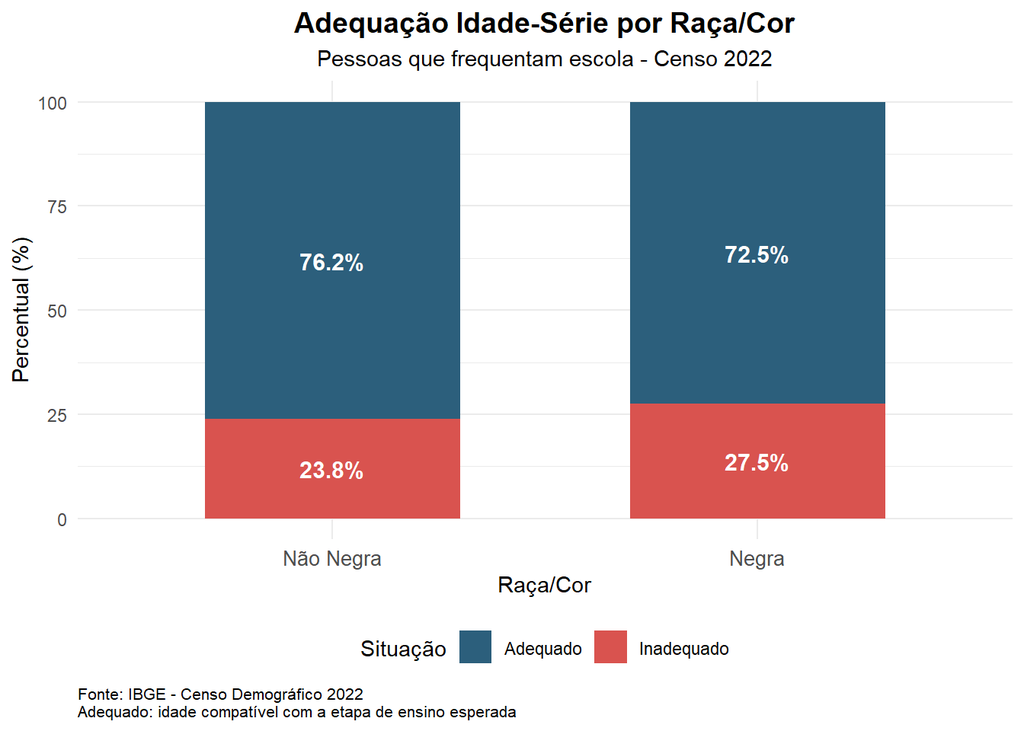

Figure 2.10: Adequação Idade-Série por Raça/Cor

Essa diferença de 3,7 pontos percentuais, embora possa parecer pequena, representa aproximadamente 1,4 milhão de estudantes negros a mais em situação de distorção idade-série em comparação com o que seria esperado se as taxas fossem iguais às dos não negros. A distorção idade-série é um indicador de trajetórias escolares irregulares, resultantes de repetência, abandono temporário ou ingresso tardio na escola.

Esse resultado evidencia que, mesmo com a universalização do acesso à educação básica, estudantes negros continuam enfrentando maiores dificuldades para progredir regularmente ao longo da trajetória escolar. Fatores como menor qualidade das escolas frequentadas, maior vulnerabilidade socioeconômica, necessidade de conciliar estudo e trabalho, e discriminação racial no ambiente escolar contribuem para essas diferenças (Hasenbalg, 2005).

A distorção idade-série tem implicações importantes para o futuro educacional e profissional dos estudantes, aumentando o risco de evasão escolar e reduzindo as chances de ingresso no ensino superior. A persistência dessa desigualdade racial, mesmo após décadas de expansão educacional, indica a necessidade de políticas específicas voltadas à permanência e ao sucesso escolar de estudantes negros.

## 2.11 Considerações sobre Acesso e Frequência Escolar

Os dados analisados nesta seção evidenciam que, embora o Brasil tenha avançado significativamente na universalização do acesso à educação básica, persistem desigualdades raciais importantes que se manifestam em diferentes dimensões da trajetória escolar.

A população negra é maioria entre os estudantes brasileiros em todas as etapas da educação básica, refletindo a composição demográfica do país. No entanto, essa maioria é mais acentuada no Ensino Fundamental e no Ensino Médio do que na Educação Infantil, sugerindo diferenças no acesso às etapas iniciais da escolarização. Além disso, a sobrerrepresentação de estudantes negros nas modalidades de Educação de Jovens e Adultos indica que esse grupo enfrenta maiores dificuldades para completar a educação básica na idade adequada.

A análise da adequação idade-série revela que estudantes negros apresentam taxas de distorção superiores às de não negros, indicando trajetórias escolares mais irregulares. Essa desigualdade é particularmente preocupante, pois a distorção idade-série está associada a maior risco de evasão escolar e piores resultados educacionais e profissionais no longo prazo.

Em conjunto, esses resultados reforçam a importância de políticas educacionais que promovam não apenas o acesso universal à escola, mas também a permanência, o sucesso e a progressão regular de estudantes negros ao longo de toda a educação básica. Estratégias como fortalecimento da educação infantil em territórios de maior vulnerabilidade, programas de apoio à permanência escolar, combate à discriminação racial nas escolas e valorização da cultura afro-brasileira no currículo são fundamentais para reduzir as desigualdades raciais na educação brasileira.

# 3 Desempenho Educacional da População Negra: Evidências do SAEB

Acesso e frequência escolar são condições necessárias, mas não suficientes, para a equidade educacional. Esta seção complementa a análise anterior incorporando indicadores de **desempenho**, a partir dos microdados do Sistema de Avaliação da Educação Básica (SAEB/INEP), agregados ao nível de município, ano, raça/cor e disciplina (Língua Portuguesa e Matemática).[^3] Diferentemente dos indicadores de acesso, que mostram a população negra como majoritária no sistema educacional, os dados de proficiência permitem avaliar se essa presença numérica se traduz em qualidade educacional equivalente.

## 3.1 Evolução da Proficiência Média por Raça/Cor

A Figura 3.1 apresenta a evolução da proficiência média nacional em Língua Portuguesa e Matemática, segundo raça/cor, ao longo das edições do SAEB disponíveis.

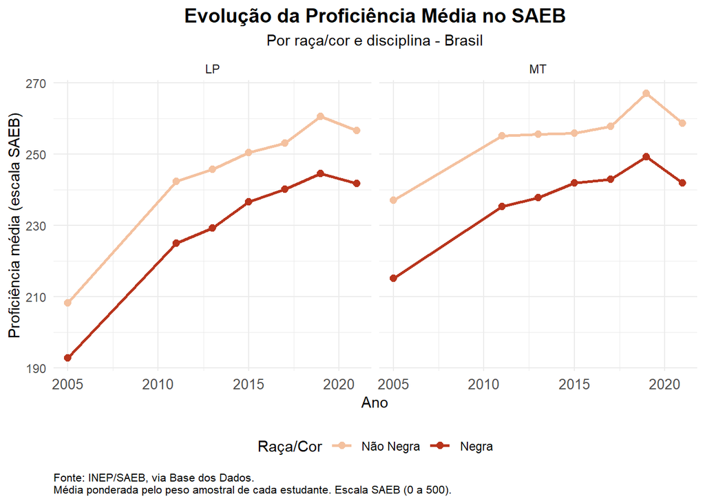

Figure 3.1: Evolução da Proficiência Média no SAEB por Raça/Cor

Em ambas as disciplinas, estudantes negros apresentam proficiência média consistentemente inferior à de estudantes não negros em todas as edições do SAEB analisadas. Esse hiato de desempenho persiste mesmo diante da maior presença numérica de estudantes negros no sistema educacional (Seção 2), evidenciando que acesso e qualidade educacional são dimensões distintas da desigualdade racial.

## 3.2 Hiato Racial de Proficiência por Região

A Figura 3.2 detalha o hiato de proficiência entre negros e não negros segundo a região do país, na edição mais recente do SAEB disponível na base (2021).

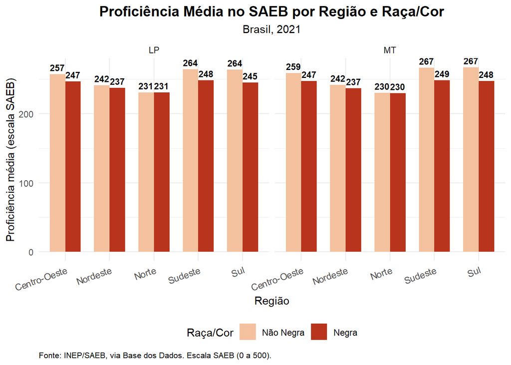

Figure 3.2: Proficiência Média no SAEB por Região e Raça/Cor

## 3.3 Hiato de Proficiência por Unidade Federativa

A análise nacional pode mascarar diferenças importantes entre estados. A Figura 3.3 apresenta o hiato médio de proficiência (não negros menos negros) agregado por Unidade Federativa, enquanto a Tabela 3.1 lista as combinações UF-disciplina com maior hiato de desempenho.[^4]

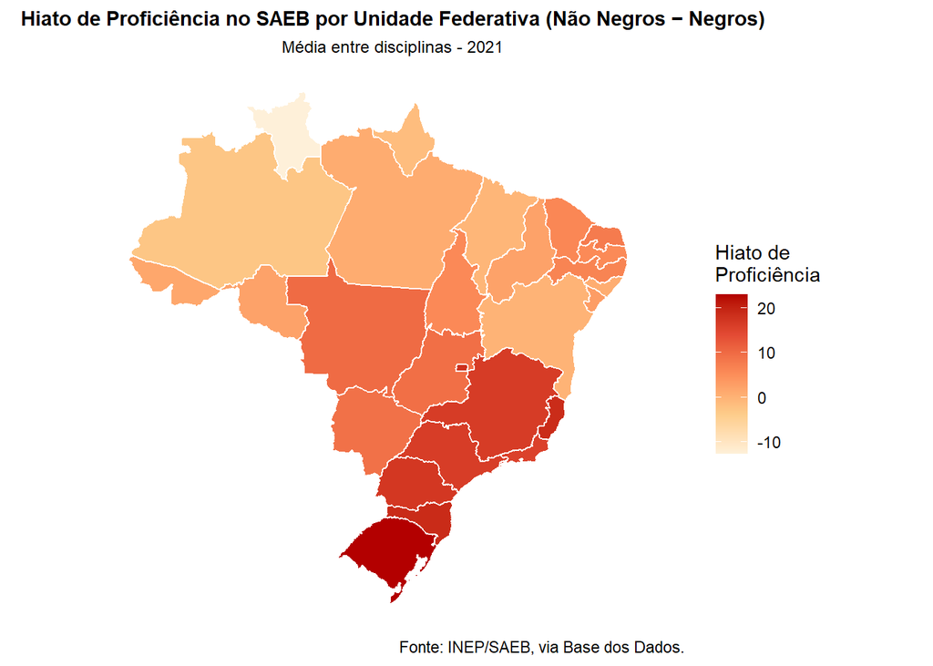

Figure 3.3: Hiato Médio de Proficiência no SAEB por Unidade Federativa

Table 3.1: UFs com maior hiato racial de proficiência no SAEB

| UF | Disciplina | Profic. Negra | Profic. Não Negra | Hiato |
| --- | --- | --- | --- | --- |
| RS | MT | 238 | 263 | 24 |
| RS | LP | 239 | 261 | 22 |
| ES | MT | 247 | 267 | 20 |
| SC | MT | 251 | 271 | 20 |
| DF | MT | 257 | 275 | 19 |
| SC | LP | 248 | 266 | 18 |
| DF | LP | 254 | 272 | 18 |
| MG | MT | 249 | 266 | 18 |
| PR | MT | 252 | 269 | 18 |
| ES | LP | 243 | 260 | 17 |

O hiato de proficiência apresenta heterogeneidade territorial relevante, com estados em que a diferença de desempenho entre negros e não negros supera substancialmente a média nacional. Essa heterogeneidade, observada já ao nível estadual, aponta para a necessidade de diagnósticos e intervenções pedagógicas focalizadas, e não apenas políticas uniformes em escala nacional.

## 3.4 Considerações sobre Desempenho Educacional

O recorte por Unidade Federativa mostra ainda que esse hiato não é uniforme no território: há estados em que a diferença de desempenho entre negros e não negros é muito mais acentuada do que a média nacional sugere, o que reforça a importância de monitoramento e políticas educacionais territorialmente direcionadas — incluindo formação docente, infraestrutura escolar e currículo antirracista — para reduzir a desigualdade racial de aprendizagem de forma efetiva. Um recorte municipal, mais granular, é desejável, mas depende de melhorias futuras na qualidade do identificador de município nas bases de microdados do SAEB (ver nota da Seção 3).

# 4 Políticas Públicas para a Educação Antirracista: SINAPIR e Programas Federais

Os hiatos de acesso, permanência e desempenho documentados nas seções anteriores não ocorrem em um vácuo institucional: há, desde os anos 2000, um arcabouço de políticas públicas federais voltado à promoção da igualdade racial na educação. Esta seção situa os resultados encontrados no contexto desse arcabouço, com destaque para o Sistema Nacional de Promoção da Igualdade Racial (SINAPIR) e para programas educacionais federais específicos.

## 4.1 O Sistema Nacional de Promoção da Igualdade Racial (SINAPIR)

O SINAPIR foi instituído pela Lei nº 12.288/2010 (Estatuto da Igualdade Racial) com o objetivo de articular e coordenar ações de promoção da igualdade racial entre União, estados, Distrito Federal e municípios, em diferentes áreas de política pública, incluindo a educação. No campo educacional, o SINAPIR se conecta diretamente a três instrumentos normativos centrais:

- A **Lei nº 10.639/2003**, que torna obrigatório o ensino de História e Cultura Afro-Brasileira e Africana na educação básica, pública e privada;
- As **Diretrizes Curriculares Nacionais para a Educação das Relações Étnico-Raciais e para o Ensino de História e Cultura Afro-Brasileira e Africana** (Resolução CNE/CP nº 1/2004), que orientam a implementação curricular da Lei 10.639/2003; e
- O **Plano Nacional de Implementação das Diretrizes Curriculares Nacionais para Educação das Relações Étnico-Raciais e para o Ensino de História e Cultura Afro-Brasileira e Africana** (PNEERQ, 2009), que detalha estratégias de formação docente, produção de material didático e gestão escolar antirracista.

Os resultados apresentados neste texto — sobrerrepresentação de estudantes negros na EJA, maior distorção idade-série, hiato de frequência em municípios específicos e, sobretudo, o hiato persistente de proficiência no SAEB — são indicadores diretamente relevantes para o monitoramento da efetividade dessas políticas. A persistência desses hiatos duas décadas após a promulgação da Lei 10.639/2003 sugere desafios na implementação curricular e na formação docente nas redes de ensino, especialmente nos estados com maior hiato de proficiência identificado na Seção 3 e nos municípios com maior hiato de frequência identificado na Seção 2.

## 4.2 Programas Federais com Potencial Impacto sobre a Desigualdade Racial Educacional

Além do arcabouço normativo do SINAPIR, diversos programas federais de educação básica têm relevância direta para a redução das desigualdades raciais identificadas, ainda que não tenham recorte racial explícito em seu desenho original: